# Rcode COHS French Validation

Lavinia Wuensch, Yoann Stussi, Théo Vernade, Eva R Pool

28 March, 2024

# French validation of the Creature of Habit Scale

## Describe the demografics of the population included in the cohes validation

```r
count.participants <- plyr::count(db.COHS.demo, c("sub"))

sum(count.participants$freq)
```

```
## [1] 681
```

```r
table_demo <- JWileymisc::egltable(c("Age", "Genre"),
                      data = db.COHS.demo[c("Age","Genre")], strict = FALSE) %>%
  kbl(caption ="Demografics of sample used for the COHS validation", digits = 2)    %>%
  kable_styling(latex_options = "HOLD_position", position = "center", full_width = F) %>%
  row_spec(0,bold=T,align='c')

table_demo
```

Demografics of sample used for the COHS validation

|  | M (SD)/N (%) |
| --- | --- |
| Age | 24.11 (7.83) |
| Genre |  |
| F | 506 (74.3%) |
| M | 169 (24.8%) |
| N/A | 6 (0.9%) |

## Verification of the prerequirements

First we need to verify the postulates of covariance and have a look at the covariances plots. For the interpretation of the KMO :

- 0.00 to 0.49 unacceptable.
- 0.50 to 0.59 miserable.
- 0.60 to 0.69 mediocre.
- 0.70 to 0.79 middling.
- 0.80 to 0.89 meritorious.
- 0.90 to 1.00 marvelous.

```r
# add formal tests for the variance covariance assumption
kmo.tab = KMO(db.COHS.cfa)

table_kmo <- knitr::kable(kmo.tab$MSAi, "html", caption = "Kmo Index", col.names = c("kmo")) %>%
  kableExtra::kable_styling(latex_options = "HOLD_position", position = "center", full_width = F) %>%
  row_spec(0,bold=T,align='c')
table_kmo
```

Kmo Index

|  | kmo |
| --- | --- |
| item1 | 0.8776385 |
| item2 | 0.8652828 |
| item3 | 0.9044056 |
| item4 | 0.7863873 |
| item5 | 0.8777490 |
| item6 | 0.8550107 |
| item7 | 0.8310125 |
| item8 | 0.8555067 |
| item9 | 0.9006214 |
| item10 | 0.9079901 |
| item11 | 0.8805790 |
| item12 | 0.8789226 |
| item13 | 0.8622103 |
| item14 | 0.8152389 |
| item15 | 0.8191419 |
| item16 | 0.8679316 |
| item17 | 0.8837137 |
| item18 | 0.8392410 |
| item19 | 0.8638605 |
| item20 | 0.8099037 |
| item21 | 0.8012920 |
| item22 | 0.8855362 |
| item23 | 0.9074968 |
| item24 | 0.8675688 |
| item25 | 0.8739287 |
| item26 | 0.8718044 |
| item27 | 0.8179426 |

```r
# bartlett test
cor_matrix <- cor(db.COHS.cfa)
cortest.bartlett(cor_matrix, n = nrow(db.COHS.cfa))
```

```
## $chisq
## [1] 4776.114
##
## $p.value
## [1] 0
##
## $df
## [1] 351
```

## Descriptive values

Descriptive values of each one of the items of the COHS

```r
# check distributions before proceeding with FA
a = psych::describe (db.COHS)

table_cohs_desc <- knitr::kable(a, "html", caption = "Descriptive values for each item of the COHS") %>%
  kableExtra::kable_styling(latex_options = "HOLD_position", position = "center", full_width = F) %>%
  row_spec(0,bold=T,align='c')

table_cohs_desc
```

Descriptive values for each item of the COHS

|  | vars | n | mean | sd | median | trimmed | mad | min | max | range | skew | kurtosis | se |
| --- | --- | --- | --- | --- | --- | --- | --- | --- | --- | --- | --- | --- | --- |
| COHS[1] | 1 | 681 | 3.654919 | 1.0886487 | 4 | 3.759633 | 1.4826 | 1 | 5 | 4 | -0.7269291 | -0.0561134 | 0.0417171 |
| COHS[2] | 2 | 681 | 3.676946 | 1.0196078 | 4 | 3.755963 | 0.0000 | 1 | 5 | 4 | -0.7701211 | -0.0739845 | 0.0390715 |
| COHS[3] | 3 | 681 | 3.049927 | 1.2580929 | 3 | 3.062385 | 1.4826 | 1 | 5 | 4 | -0.0584723 | -1.1444339 | 0.0482102 |
| COHS[4] | 4 | 681 | 3.323054 | 1.1936893 | 4 | 3.374312 | 1.4826 | 1 | 5 | 4 | -0.4230418 | -0.9669093 | 0.0457423 |
| COHS[5] | 5 | 681 | 2.528634 | 1.2233582 | 2 | 2.455046 | 1.4826 | 1 | 5 | 4 | 0.4198128 | -0.9325013 | 0.0468792 |
| COHS[6] | 6 | 681 | 3.547724 | 1.0864804 | 4 | 3.612844 | 1.4826 | 1 | 5 | 4 | -0.5379818 | -0.4684291 | 0.0416340 |
| COHS[7] | 7 | 681 | 3.795888 | 1.1508491 | 4 | 3.932110 | 1.4826 | 1 | 5 | 4 | -0.9033837 | -0.0993613 | 0.0441006 |
| COHS[8] | 8 | 681 | 3.713656 | 1.2679088 | 4 | 3.875229 | 1.4826 | 1 | 5 | 4 | -0.8226900 | -0.4324924 | 0.0485864 |
| COHS[9] | 9 | 681 | 2.998532 | 1.3596056 | 3 | 2.998165 | 1.4826 | 1 | 5 | 4 | 0.0026511 | -1.3150029 | 0.0521002 |
| COHS[10] | 10 | 681 | 2.875184 | 1.3440449 | 3 | 2.844037 | 1.4826 | 1 | 5 | 4 | 0.0933171 | -1.2769884 | 0.0515039 |
| COHS[11] | 11 | 681 | 2.668135 | 1.2964876 | 2 | 2.603670 | 1.4826 | 1 | 5 | 4 | 0.2552814 | -1.1989458 | 0.0496815 |
| COHS[12] | 12 | 681 | 3.518355 | 1.0682728 | 4 | 3.581651 | 1.4826 | 1 | 5 | 4 | -0.6656201 | -0.3339031 | 0.0409363 |
| COHS[13] | 13 | 681 | 2.979442 | 1.0486071 | 3 | 2.970642 | 1.4826 | 1 | 5 | 4 | 0.0561893 | -0.8943618 | 0.0401827 |
| COHS[14] | 14 | 681 | 3.243759 | 1.2435338 | 3 | 3.289908 | 1.4826 | 1 | 5 | 4 | -0.2159746 | -1.1022096 | 0.0476523 |
| COHS[15] | 15 | 681 | 3.346549 | 1.0793615 | 3 | 3.385321 | 1.4826 | 1 | 5 | 4 | -0.3829849 | -0.4770723 | 0.0413612 |
| COHS[16] | 16 | 681 | 3.086637 | 1.3071570 | 3 | 3.108257 | 1.4826 | 1 | 5 | 4 | -0.1718809 | -1.2289260 | 0.0500904 |
| COHS[17] | 17 | 681 | 3.412628 | 1.2205660 | 4 | 3.484404 | 1.4826 | 1 | 5 | 4 | -0.4174103 | -0.9096303 | 0.0467722 |
| COHS[18] | 18 | 681 | 3.447871 | 1.3006782 | 4 | 3.539449 | 1.4826 | 1 | 5 | 4 | -0.3802938 | -1.0873031 | 0.0498421 |
| COHS[19] | 19 | 681 | 2.220264 | 1.2047457 | 2 | 2.095413 | 1.4826 | 1 | 5 | 4 | 0.7310692 | -0.5992538 | 0.0461660 |
| COHS[20] | 20 | 681 | 4.187959 | 1.0543616 | 4 | 4.405505 | 1.4826 | 1 | 5 | 4 | -1.4692666 | 1.5635131 | 0.0404032 |
| COHS[21] | 21 | 681 | 2.627019 | 1.2621543 | 2 | 2.563303 | 1.4826 | 1 | 5 | 4 | 0.2961056 | -1.0965728 | 0.0483659 |
| COHS[22] | 22 | 681 | 3.032305 | 1.1397170 | 3 | 3.066055 | 1.4826 | 1 | 5 | 4 | -0.1464303 | -0.9865412 | 0.0436741 |
| COHS[23] | 23 | 681 | 2.417034 | 1.2934009 | 2 | 2.310092 | 1.4826 | 1 | 5 | 4 | 0.5045183 | -1.0059628 | 0.0495632 |
| COHS[24] | 24 | 681 | 3.273128 | 1.2362171 | 4 | 3.341284 | 1.4826 | 1 | 5 | 4 | -0.4720924 | -0.8492936 | 0.0473719 |
| COHS[25] | 25 | 681 | 2.930984 | 1.2670927 | 3 | 2.913762 | 1.4826 | 1 | 5 | 4 | -0.0351740 | -1.2122039 | 0.0485551 |
| COHS[26] | 26 | 681 | 3.162996 | 1.4301931 | 3 | 3.203670 | 1.4826 | 1 | 5 | 4 | -0.1937988 | -1.3369050 | 0.0548051 |
| COHS[27] | 27 | 681 | 3.765051 | 0.9286361 | 4 | 3.855046 | 1.4826 | 1 | 5 | 4 | -0.8285168 | 0.7261281 | 0.0355854 |
| COHS_routine | 28 | 681 | 55.080764 | 9.2375957 | 56 | 55.405505 | 8.8956 | 23 | 79 | 56 | -0.3612547 | 0.2475669 | 0.3539854 |
| COHS_automaticity | 29 | 681 | 31.403818 | 8.7893611 | 32 | 31.473395 | 8.8956 | 11 | 53 | 42 | -0.0223353 | -0.5447418 | 0.3368090 |

## Network analysis for the COHS

First we run exploratory network analysis to identify the communities

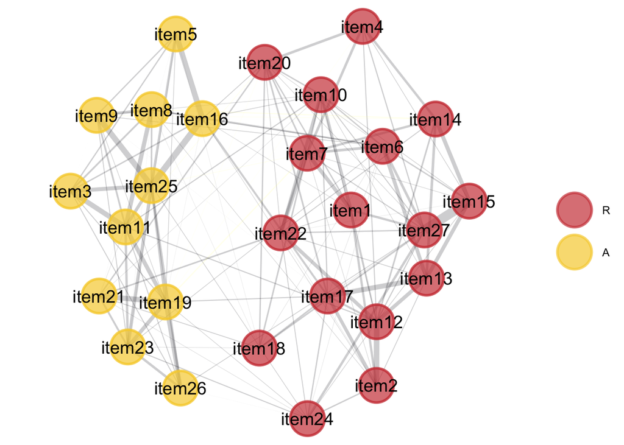

```r
cohs.ega <- EGAnet::EGA(db.COHS.cfa, model = "glasso", plot.EGA = F)

ega.figure <- plot(cohs.ega,
                   node.color = c(pal[6], pal[9]),
                   edge.color = c(pal[1], pal[10]),
                   legend.names = c("R", "A"),
                   edge.alpha = 0.1,
                   node.alpha = 0.7)

ega.figure
```

```r
dev.print(pdf, file.path(figures_path,'Supplementary_Figure_EGAnet.pdf'))
```

```r
dev.off()
```

Display the standardized loadings of each item to the two communities

```r
net.loads(cohs.ega)$std
```

```
##                   1            2
## item27  0.325123205  0.011398372
## item12  0.287117567  0.016767621
## item7   0.285280893 -0.025570328
## item15  0.278944483  0.000000000
## item13  0.273081696  0.000000000
## item17  0.219192830  0.047400852
## item22  0.212245964  0.024587311
## item1   0.195624641  0.007869036
## item10  0.188259714  0.039073355
## item2   0.184937110  0.014199950
## item14  0.182000586 -0.022399114
## item6   0.169638767  0.056602962
## item20  0.153029547  0.045151127
## item4   0.136200524 -0.003290324
## item24  0.089439431  0.040882661
## item18  0.083992156  0.024230252
## item25 -0.016136873  0.480306285
## item11  0.034720265  0.338140893
## item19 -0.042654698  0.337398649
## item3   0.000000000  0.235068964
## item23  0.026757952  0.230836024
## item16  0.067226535  0.223671166
## item9   0.021321089  0.201831798
## item8   0.043197425  0.185353860
## item5   0.002741271  0.174793669
## item26  0.010609232  0.165238784
## item21  0.058964007  0.115318144
```

Now we can run a bootstrap EFA with the boot strap of the efa to extract the stability indexes

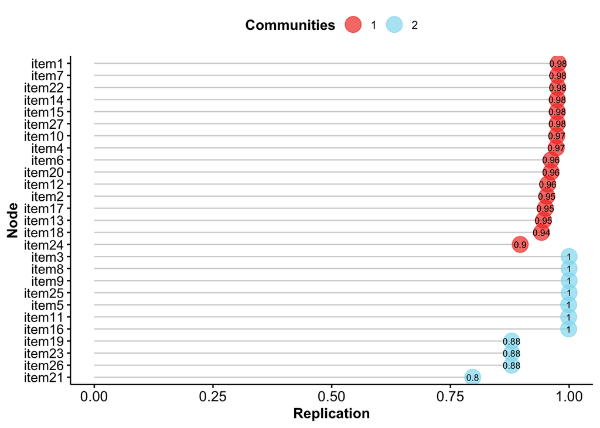

```r
cohs.boot <- EGAnet::bootEGA(db.COHS.cfa, model = "glasso", type = "parametric", iter = 1000, seed = 6724, plot.typical.ega = FALSE, plot.typicalStructure = FALSE)
```

Now we want to see how many times (out of 1’000) the two factors solution was selected during the bootstraping

```r
cohs.boot$frequency
```

```
##   # of Factors Frequency
## 1            2     0.798
## 3            3     0.153
## 2            4     0.045
## 4            5     0.004
```

Here we can see that the two factor solution is chosen almost 80% of the times. Now we can try to have a look at the item stability (how many time one item was attributed to one factor during the bootstrap procedure)

```r
cohs.sc <- EGAnet::dimensionStability(cohs.boot, structure =cohs.ega$wc, IS.plot = F)

cohs.sc$item.stability$plot +
    ggplot2::scale_color_manual(values=c(pal[6], pal[9]), labels =c("R","A"))
```

```r
dev.print(pdf, file.path(figures_path,'Supplementary_Figure_EGAboot.pdf'))
```

```r
dev.off()
```

We can see that overall the item attribution is quite stable, with perhaps an exception with item 21 (though is not terrible).

```r
item.tab <- cohs.sc$item.stability$item.stability$all.dimensions

table_boot_item <- knitr::kable(item.tab, "html",caption = "Bootstrap procedure for the EGA dimensions") %>%
  kableExtra::kable_styling(latex_options = "HOLD_position", position = "center", full_width = F) %>%
  row_spec(0,bold=T,align='c')


table_boot_item
```

Bootstrap procedure for the EGA dimensions

|  | 1 | 2 | 3 | 4 | 5 |
| --- | --- | --- | --- | --- | --- |
| item1 | 0.977 | 0.000 | 0.023 | 0.000 | 0.000 |
| item2 | 0.953 | 0.000 | 0.044 | 0.003 | 0.000 |
| item3 | 0.000 | 1.000 | 0.000 | 0.000 | 0.000 |
| item4 | 0.973 | 0.000 | 0.025 | 0.002 | 0.000 |
| item5 | 0.000 | 0.999 | 0.000 | 0.001 | 0.000 |
| item6 | 0.962 | 0.000 | 0.037 | 0.001 | 0.000 |
| item7 | 0.976 | 0.000 | 0.024 | 0.000 | 0.000 |
| item8 | 0.000 | 1.000 | 0.000 | 0.000 | 0.000 |
| item9 | 0.000 | 1.000 | 0.000 | 0.000 | 0.000 |
| item10 | 0.974 | 0.000 | 0.026 | 0.000 | 0.000 |
| item11 | 0.000 | 0.999 | 0.001 | 0.000 | 0.000 |
| item12 | 0.955 | 0.000 | 0.042 | 0.003 | 0.000 |
| item13 | 0.946 | 0.000 | 0.052 | 0.001 | 0.001 |
| item14 | 0.975 | 0.000 | 0.022 | 0.002 | 0.001 |
| item15 | 0.975 | 0.000 | 0.022 | 0.002 | 0.001 |
| item16 | 0.000 | 0.999 | 0.000 | 0.001 | 0.000 |
| item17 | 0.950 | 0.000 | 0.045 | 0.005 | 0.000 |
| item18 | 0.942 | 0.007 | 0.044 | 0.006 | 0.001 |
| item19 | 0.000 | 0.879 | 0.085 | 0.034 | 0.002 |
| item20 | 0.962 | 0.000 | 0.035 | 0.003 | 0.000 |
| item21 | 0.027 | 0.797 | 0.121 | 0.041 | 0.003 |
| item22 | 0.976 | 0.000 | 0.024 | 0.000 | 0.000 |
| item23 | 0.000 | 0.879 | 0.085 | 0.034 | 0.002 |
| item24 | 0.897 | 0.024 | 0.064 | 0.008 | 0.000 |
| item25 | 0.000 | 1.000 | 0.000 | 0.000 | 0.000 |
| item26 | 0.000 | 0.879 | 0.085 | 0.034 | 0.002 |
| item27 | 0.975 | 0.000 | 0.022 | 0.002 | 0.001 |

What we can see is that item 21 often times (12%) loads into a third dimension (the number of structural dimensions of a network can be different than the number of factors that is not a bug)

Let’s have a look at the dimension stability

```r
cohs.sc$dimension.stability
```

```
## $structural.consistency
##     1     2
## 0.848 0.807
##
## $average.item.stability
##         1         2
## 0.9605000 0.9482727
```

## Correlation between Routine and Automaticity

Let’s have a look at the correlation between the two expected subscales

```
## Call:corr.test(x = db.COHS$COHS_automaticity, y = db.COHS$COHS_routine)
## Correlation matrix
## [1] 0.25
## Sample Size
## [1] 681
## These are the unadjusted probability values.
##   The probability values  adjusted for multiple tests are in the p.adj object.
## [1] 0
##
##  Confidence intervals based upon normal theory.  To get bootstrapped values, try cor.ci
##       raw.lower raw.r raw.upper raw.p lower.adj upper.adj
## NA-NA      0.18  0.25      0.32     0      0.18      0.32
```